# R1 & R2: Intro to R

# Data visualization in base R

We will spend a lot more time later in the boot camp on data visualization, but today we will briefly introduce some functions for visualization that are included in base R. These functions are useful to quickly visualize data in early phases of analysis, and their syntax is often incorporated into other packages. For more advanced and aesthetically pleasing data visualization, you will want to use the `ggplot2` package, which we will go over in detail on Day 3.

## Histograms

Histograms are a simple and useful way to visualize the distribution of a variable. For example, let’s plot a histogram of life expectancy from the `gapminder07` data frame:

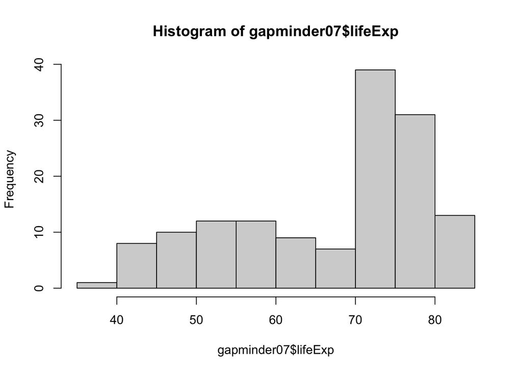

```r
hist(gapminder07$lifeExp)
```

By reading the help file for the `hist()` function, we can identify several arguments that can change the aesthetics of the plot. The `breaks =` argument controls the number of breaks on the x-axis.

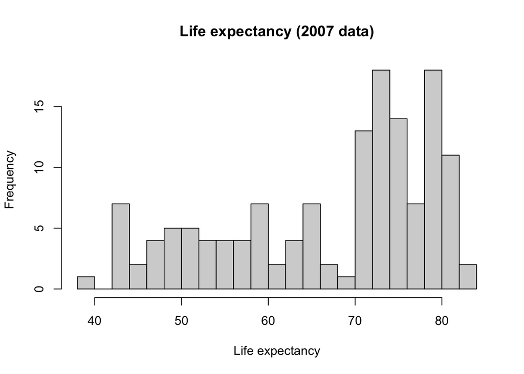

```r
hist(gapminder07$lifeExp, breaks=20,
     main="Life expectancy (2007 data)", ylab="Frequency", xlab="Life expectancy")
```

## Scatterplots

The simplest way to plot the relationship between two variables is a scatterplot. If you provide two variables to the `plot()` function in R, it produces a scatterplot. Let’s try it with life expectancy and GDP per capita in the `gapminder07` data frame. Recall that `~` means “a function of”, so we will put the y-axis variable on the left and the x-axis variable on the right.

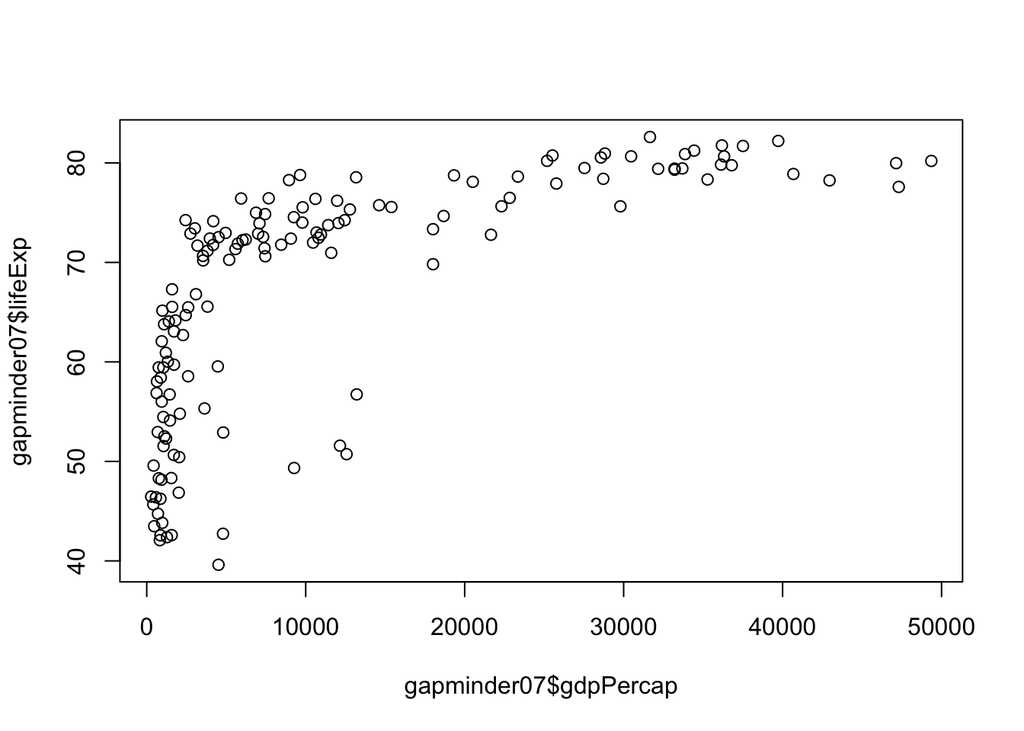

```r
plot(gapminder07$lifeExp ~ gapminder07$gdpPercap)
```

Again, we can add axes and labels:

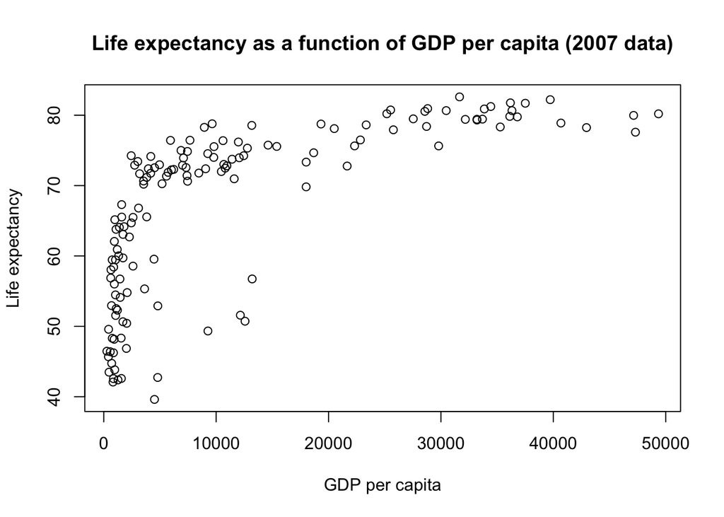

```r
plot(gapminder07$lifeExp ~ gapminder07$gdpPercap, main="Life expectancy as a function of GDP per capita (2007 data)", xlab="GDP per capita", ylab="Life expectancy")
```

Perhaps we want to add a line indicating the mean value of life expectancy. We can do this by using the `abline()` function to add a line after creating a plot. Adding multiple layers to a plot is much more intuitive and flexible with the `ggplot2` package, which we will explore on Day 3.

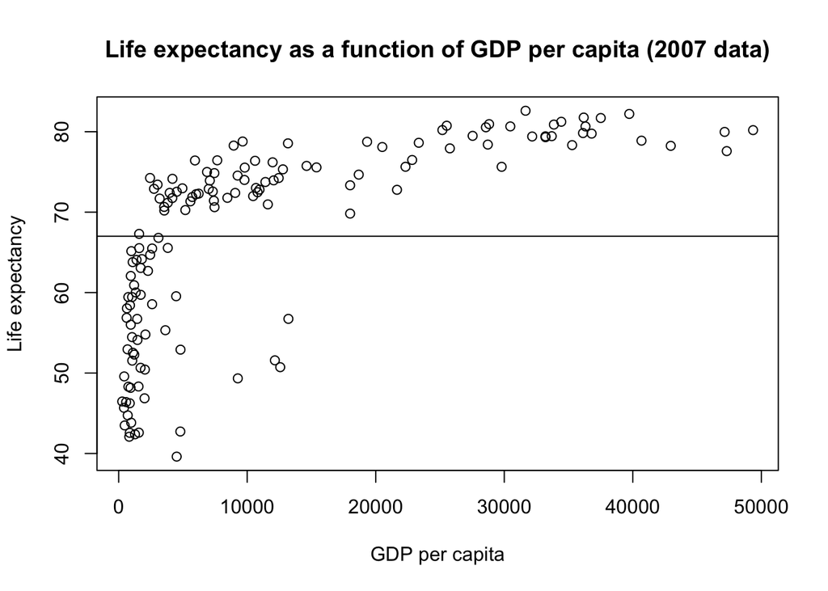

```r
plot(gapminder07$lifeExp ~ gapminder07$gdpPercap, main="Life expectancy as a function of GDP per capita (2007 data)", xlab="GDP per capita", ylab="Life expectancy")
abline(h = mean(gapminder07$lifeExp))
```